# Longitudinal Anatomy of Covid-19 Distress: For High School Students

2021-JUNE-17

## Interest: Longitudinal Psychology

- How different will your beliefs, attituds, and values be when your graduate from University?
- Will you want the same things?
- What might you regret when you are old?

## Case study in Longitudinal Psychology

- How did Covid-19 affected people?
- What do these effects tell us about human psychology?

## The New Zealand Attitudes and Values Study

- Planned 20-year longitudinal study, currently in its 12\(^{th}\) year.
- Sample frame drawn randomly from NZ Electoral Roll.
- Employment, Health, Relationships, Beliefs, Values, Wellbeing…
- Current sample contains `36524` unique people, which is \(>\) 1% of the NZ adult population.
- Here, *N* = 8640 longitudinal participants who responded to **both** the 2018/19 and 2019/20 NZAVS waves.

## What we did with our time?

## Slept - more

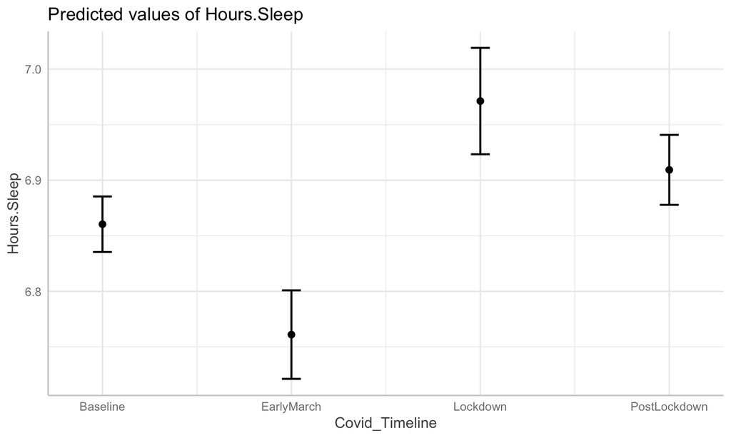

## Exercised - more

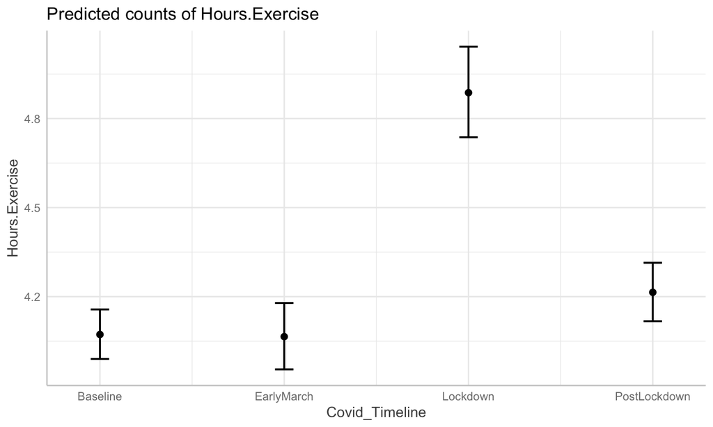

## Hours with friends - loss

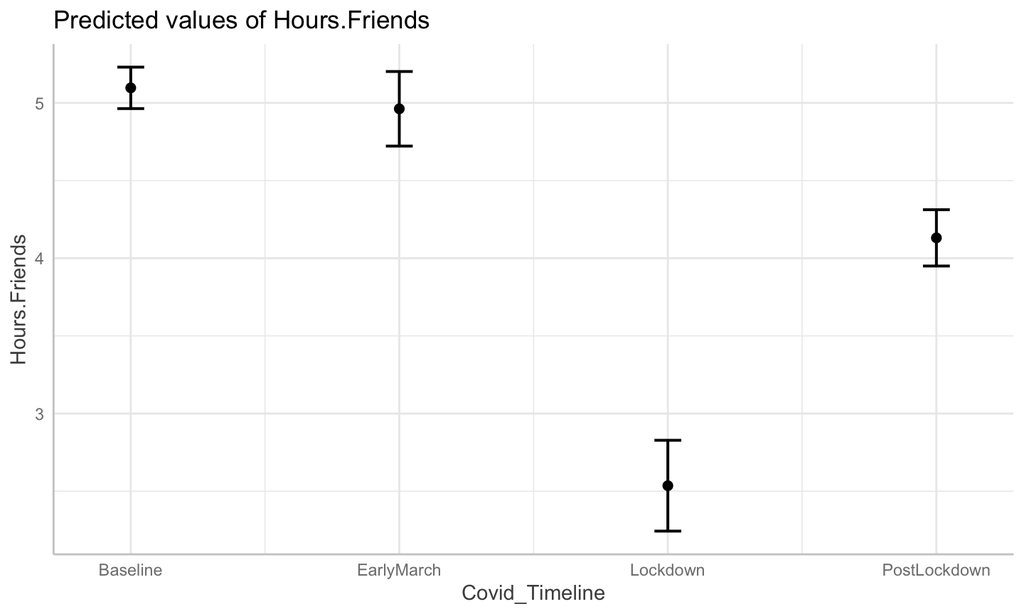

## Hours with family - more

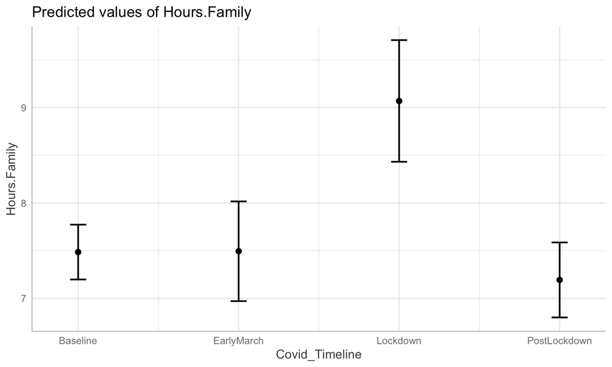

## Hours with community - loss

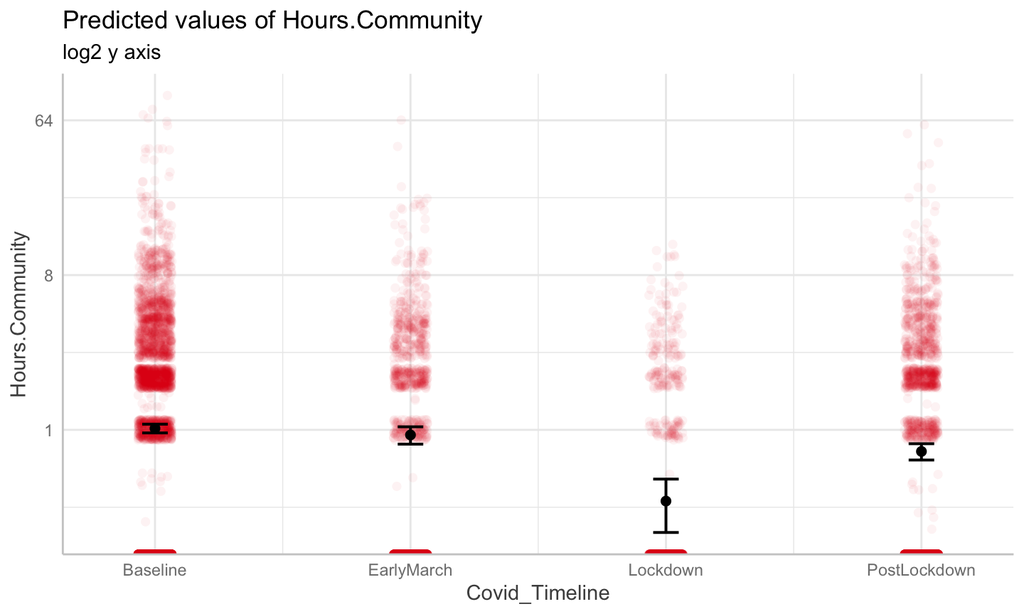

## Hours news - big gain

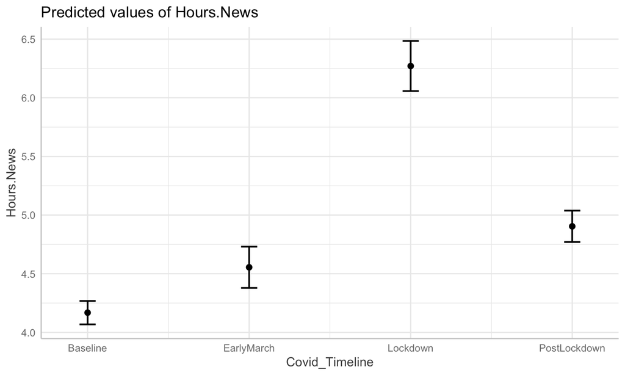

## Hours TV - yes

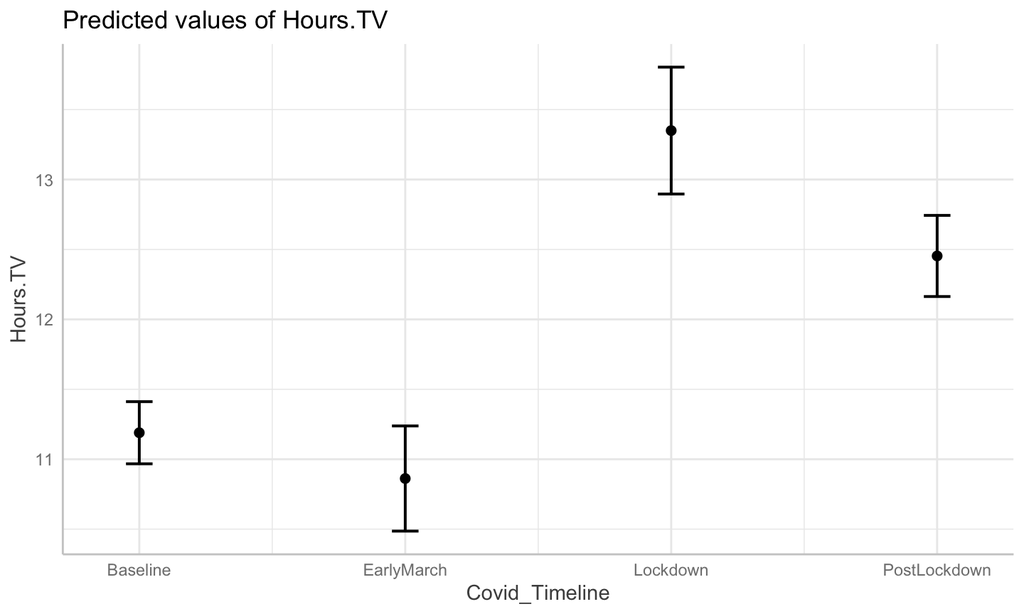

## Computer games - yes

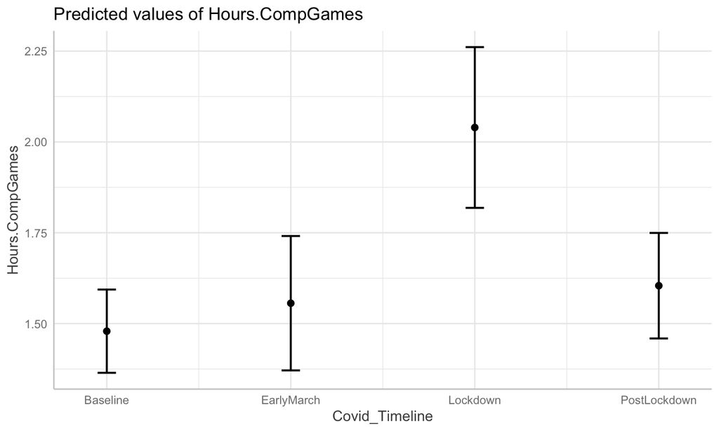

## Hours internet - big gain

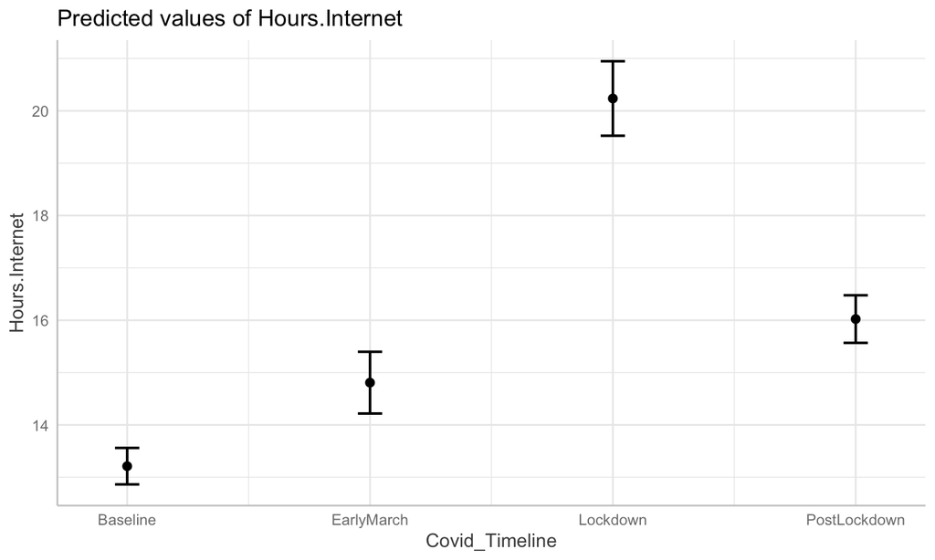

## Hours social media - big gain

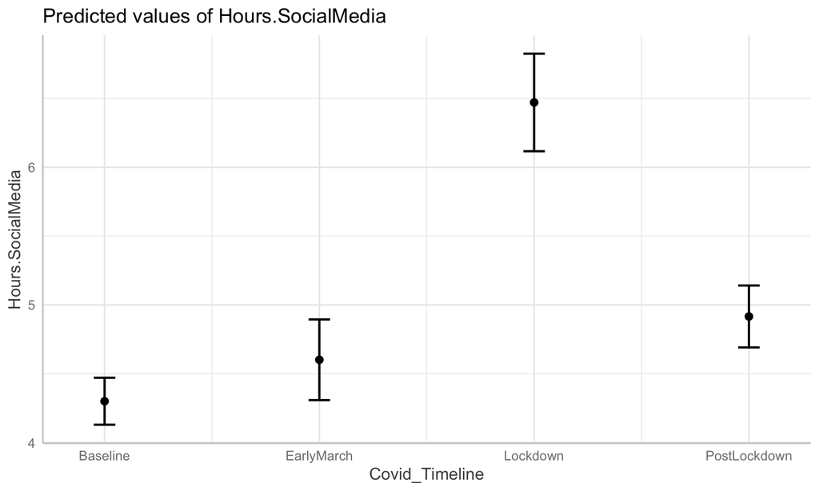

## Hours work - fewer

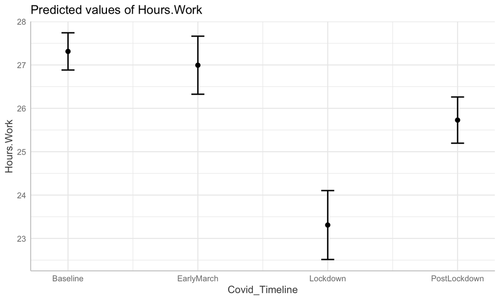

## Hours housework - more

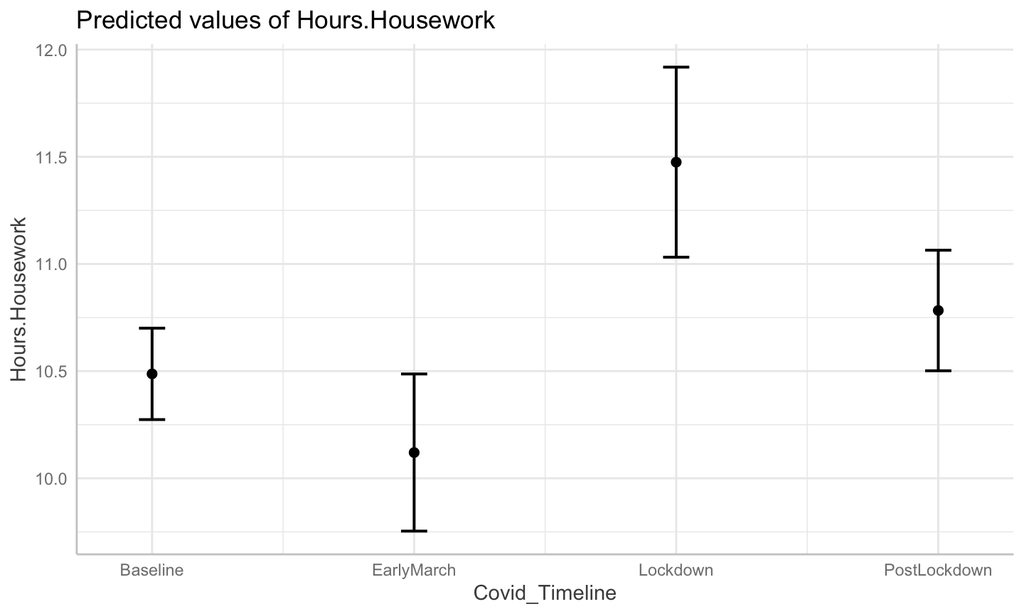

## Hours commuting - much less

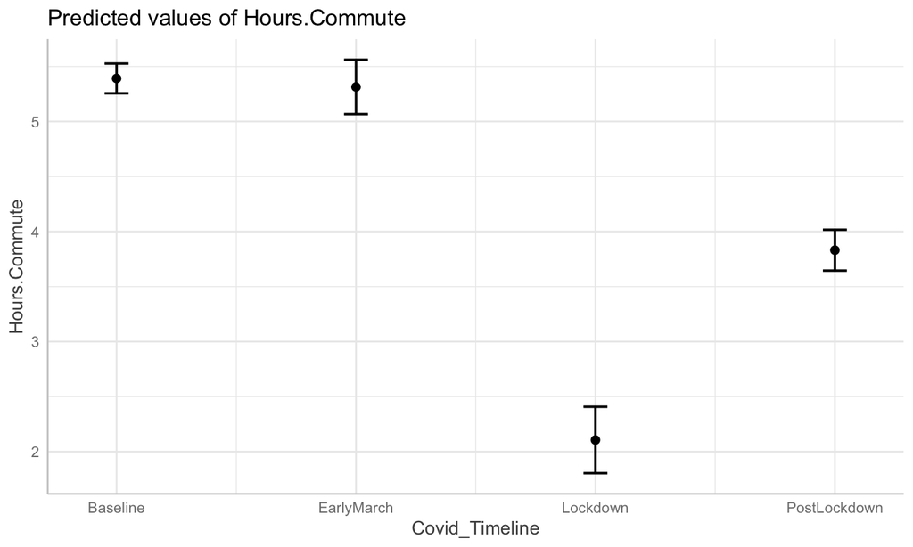

## Core psycho-physical effects

## Fatigue - huge drop

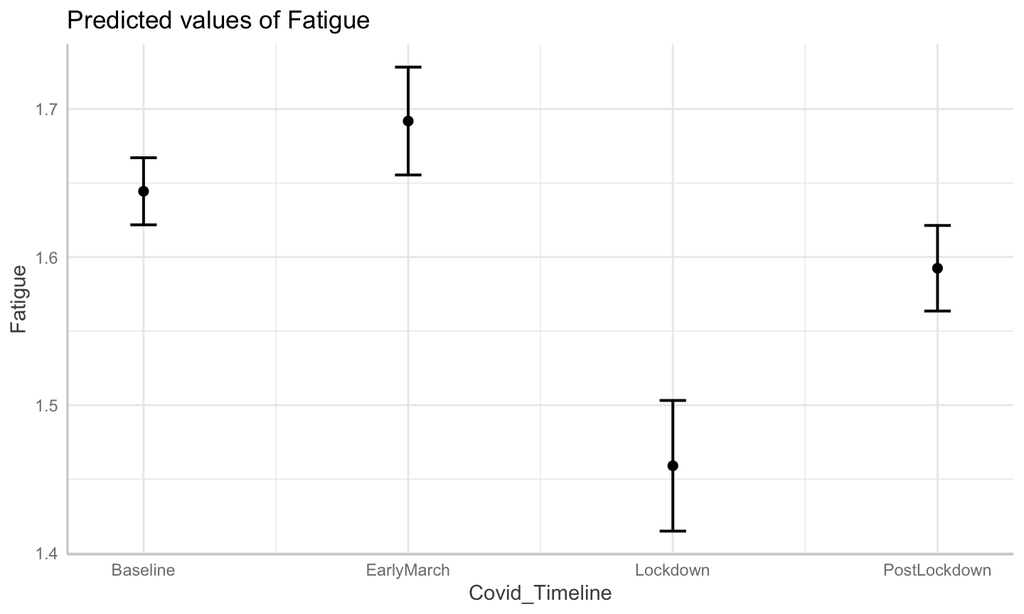

## Meaning of life

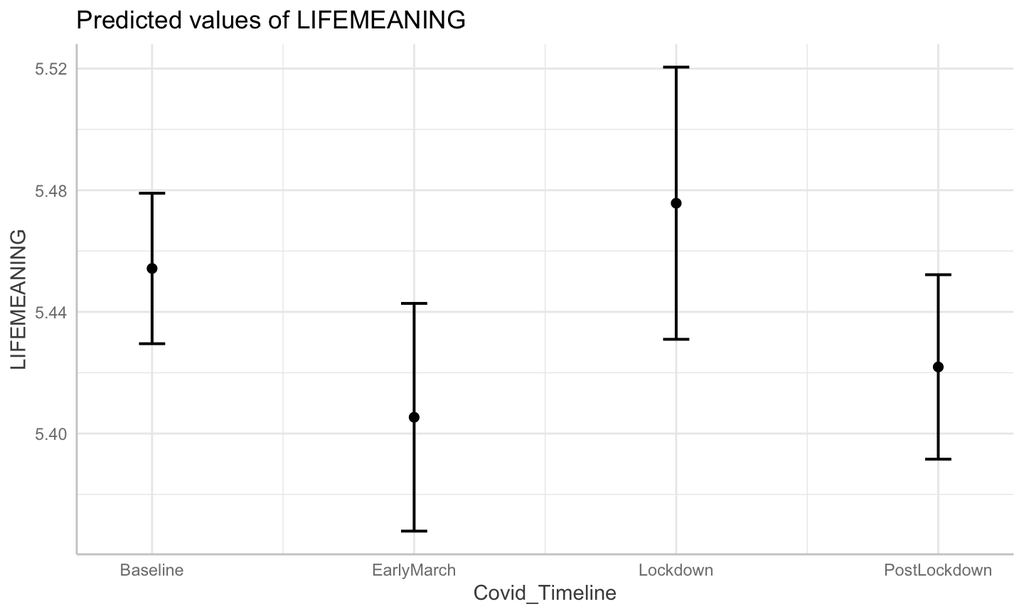

## Sat with gov’t - big gain

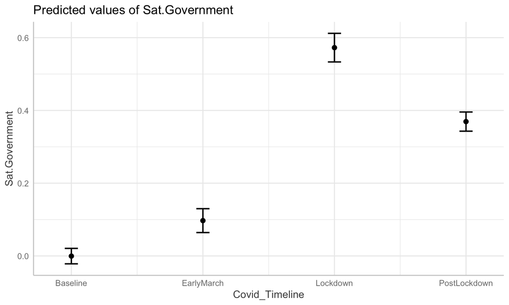

## Future security - gain > March

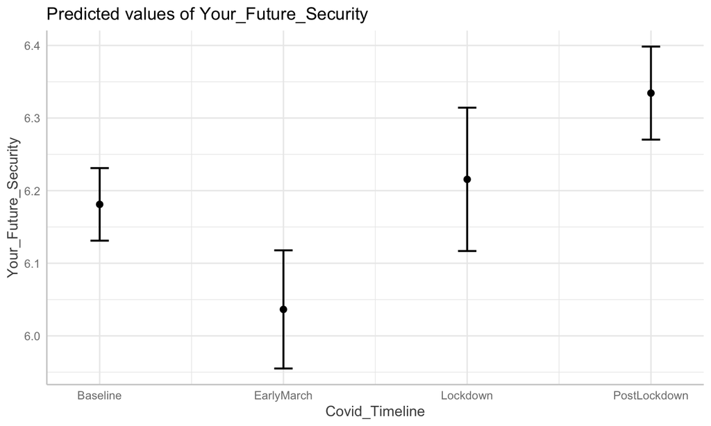

## Job security - March slide

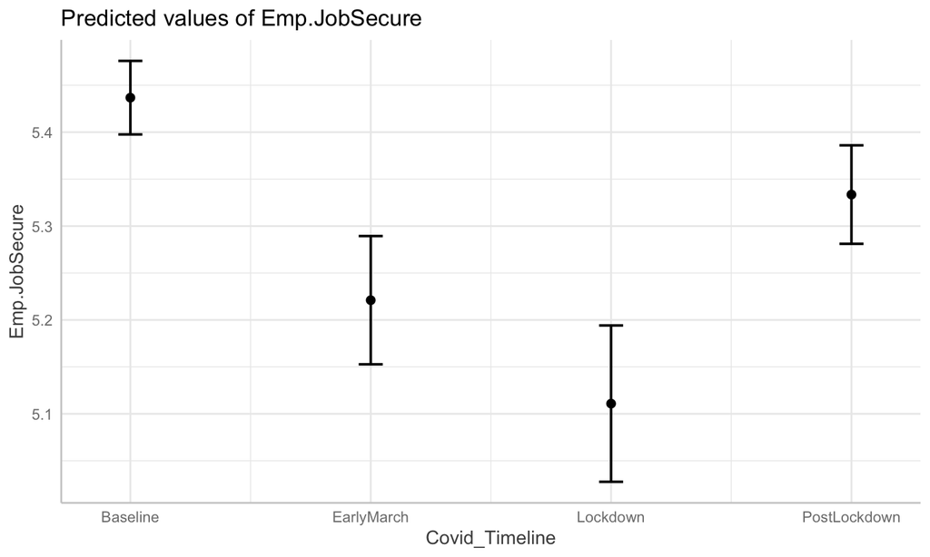

## Partner conflict - steady

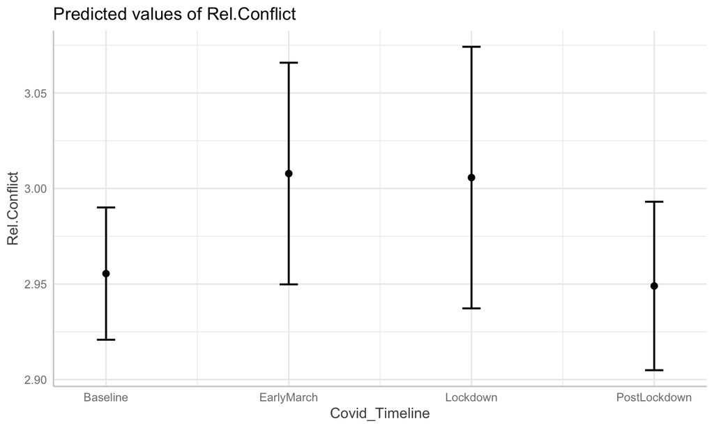

## Partner satisfaction - steady-ish?

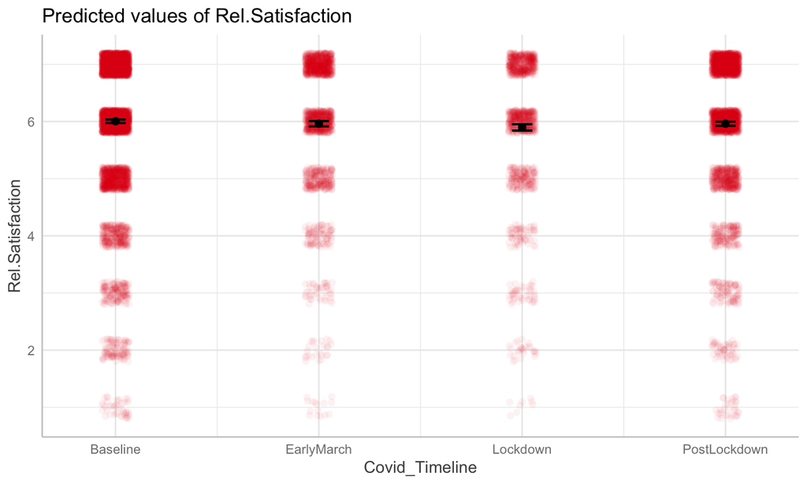

## Business optimism - slide

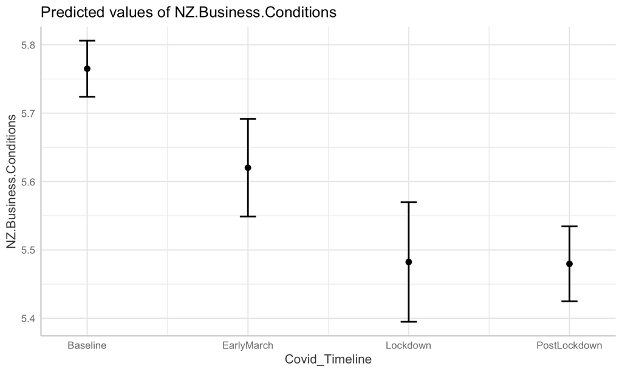

## Economic outlook - slide

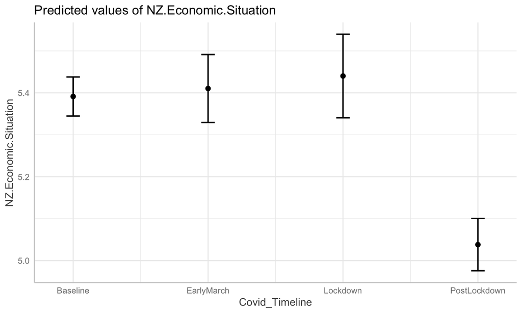

## Kessler-6 distress

## Kessler-items

during the past 30 days, how often did…

(a)\(\dots\)you feel hopeless; (b)\(\dots\)you feel so depressed that nothing could cheer you up; (c)\(\dots\)you feel restless or fidgety; (d)\(\dots\)you feel that everything was an effort; (e)\(\dots\)you feel worthless; (f)\(\dots\) you feel nervous?

Answers: None of the time; A little of the time; Some of the time; Most of the time; All of the time."

## Pandemic distress

1. Distress elevation from SARS-CoV-2 health risks (Qiu et al. 2020)(Twenge and Joiner 2020)
2. Distress elevation from economic downturn (Twenge and Joiner 2020);
3. Distress elevation from social isolation (Van Bavel et al. 2020).
4. Distress buffering from greater institutional trust (Sibley et al. 2020).
5. Distress buffering from an elevated sense of civic community (Sibley et al. 2020).

## Distress by timeline

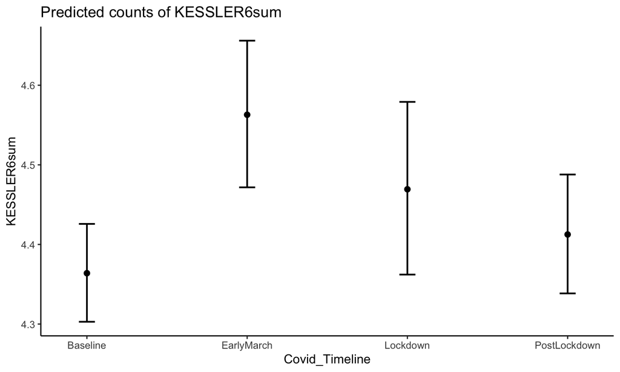

## Distress was all about March!

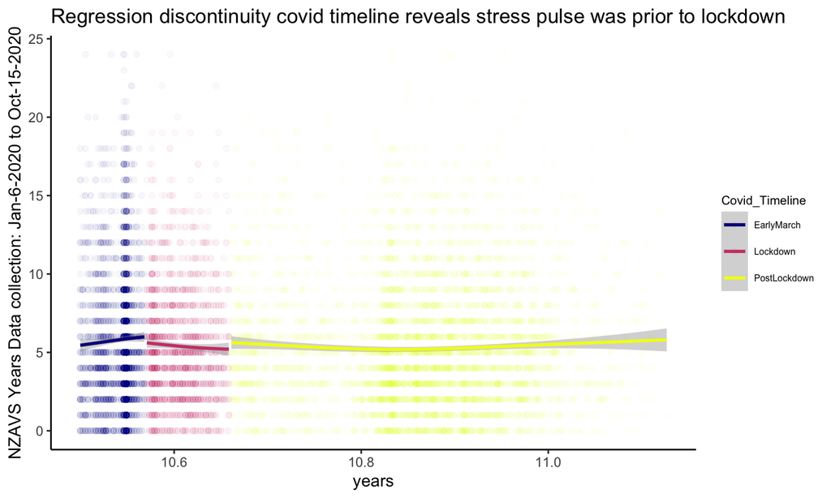

## Mediation Models

- Manipulate X, measure M and Y
- Regress M on X; Y on X and M

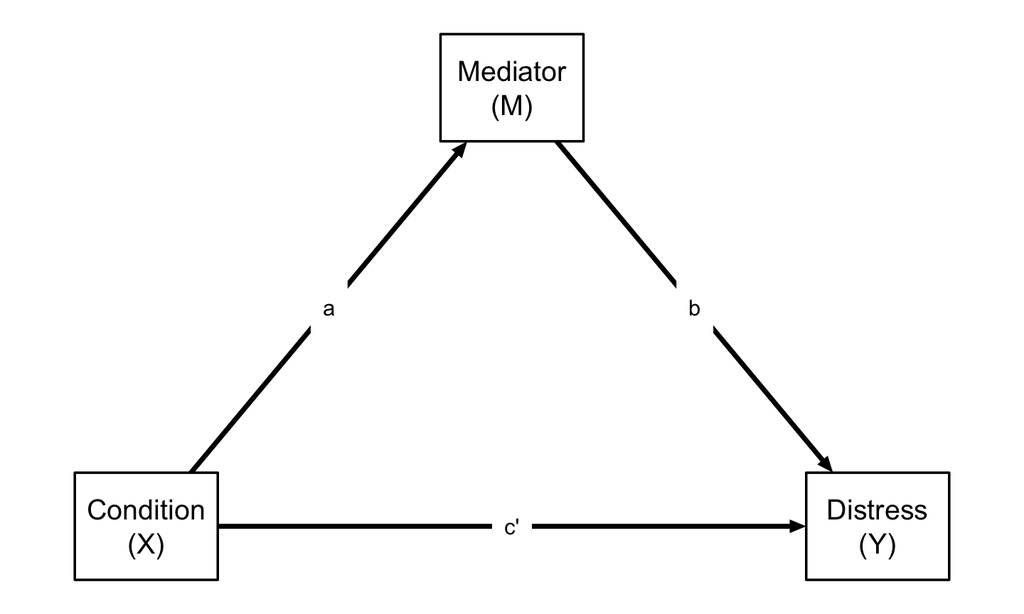

## Assumptions

- Y does not affect M
- No 3rd variable on M to Y relationship
- M is measured without error
- Y and M residuals are not correlated (Vuorre 2020)

## Fatigue: DAG

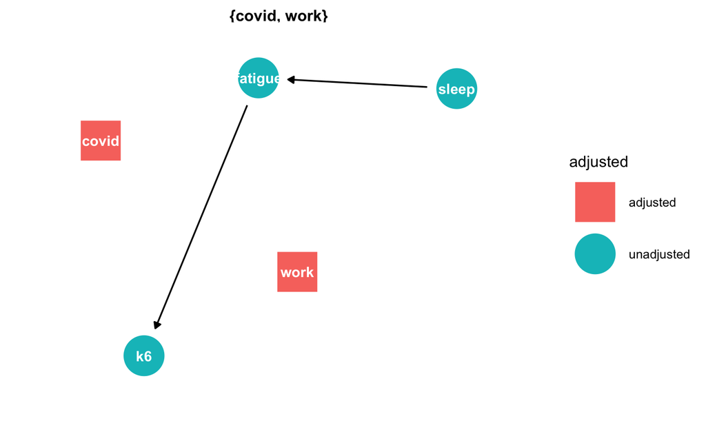

## Mediation: Fatigue

## Results: fatigue - March

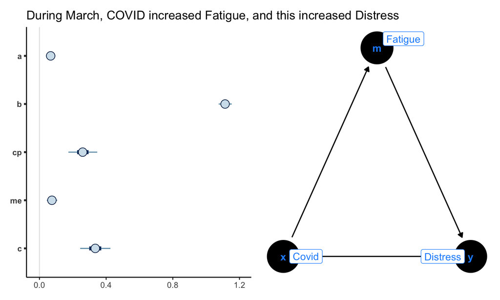

## Results: fatigue - L4

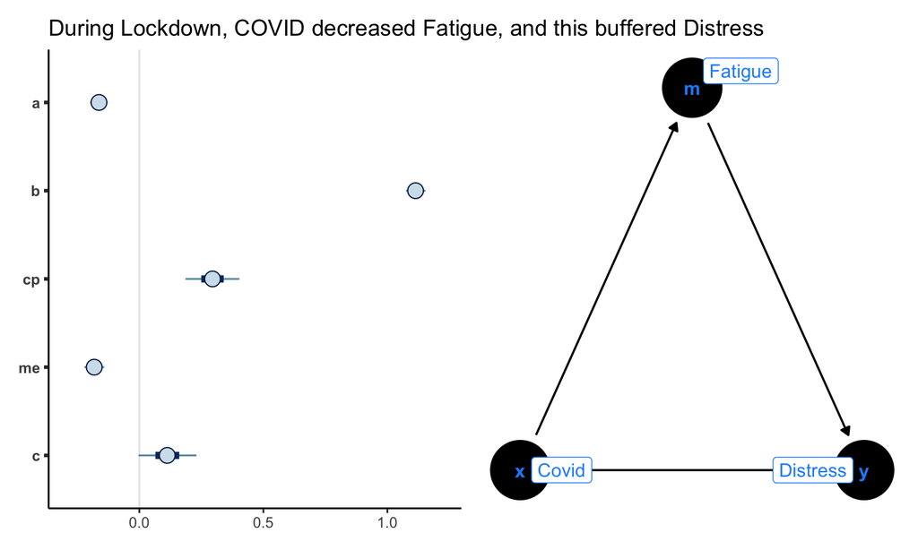

## Mediation: Future Security

## Future Security: DAG

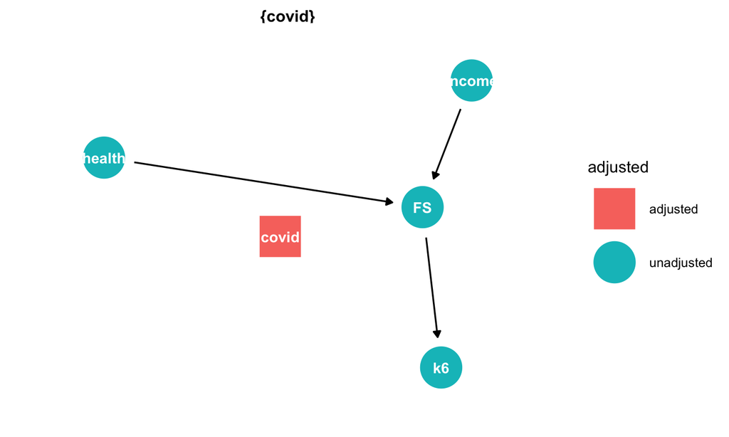

## F.Security - March

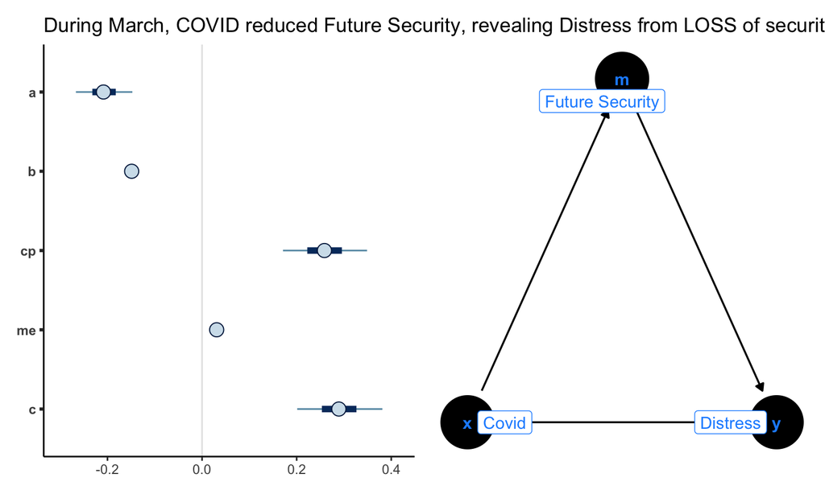

## F.Security - L4

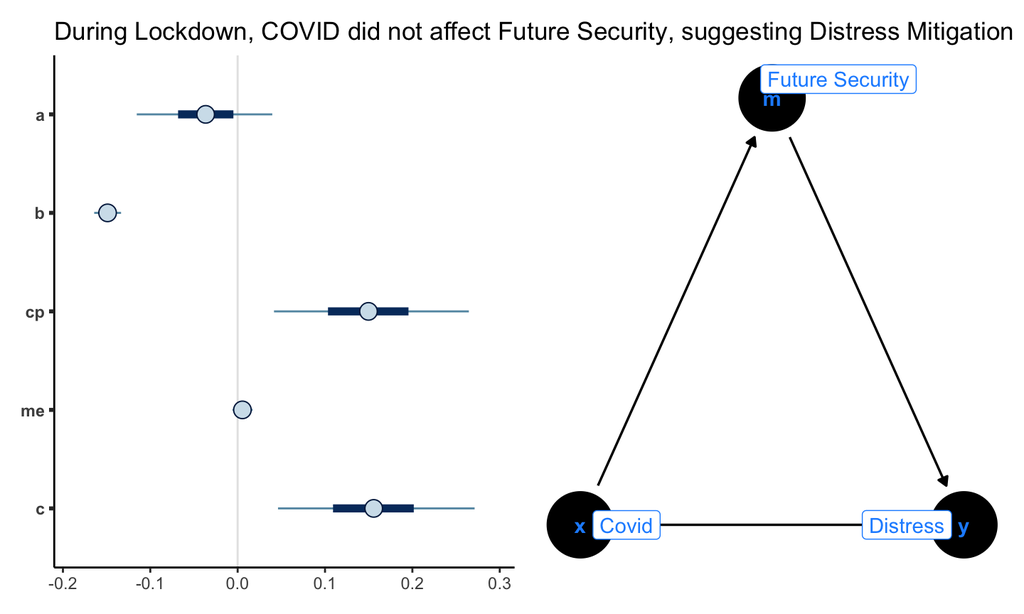

## Recap

- L4-Lockdown eased distress
- Rest and Future Security were buffers
- Relevant to clarifying what people really need?
- contact: joseph.bulbulia@vuw.ac.nz

## Thanks

- Prof Chris G. Sibley & the NZAVS team
- Dr.Matti Vuorre (former VUW graduate, now at Oxford) for his [workshop](https://mvuorre.github.io/brms-workshop/)
- NZAVS participants

## Funders

Templeton Religion Trust Grant 0196

## Slides here

https://go-bayes.github.io/reports/posts/covid/

## Bibliography

Qiu, Jianyin, Bin Shen, Min Zhao, Zhen Wang, Bin Xie, and Yifeng Xu. 2020. “A Nationwide Survey of Psychological Distress Among Chinese People in the COVID-19 Epidemic: Implications and Policy Recommendations.” *Gen Psychiatr* 33 (2): e100213.

Sibley, Chris G, Lara M Greaves, Nicole Satherley, Marc S Wilson, Nickola C Overall, Carol H J Lee, Petar Milojev, et al. 2020. “Effects of the COVID-19 Pandemic and Nationwide Lockdown on Trust, Attitudes Towards Government, and Wellbeing.” *American Psychologist*.

Twenge, Jean, and Thomas E Joiner. 2020. “Mental Distress Among u.s. Adults During the COVID-19 Pandemic.” PsyArXiv. https://doi.org/10.31234/osf.io/wc8ud.

Van Bavel, Jay J, Katherine Baicker, Paulo S Boggio, Valerio Capraro, Aleksandra Cichocka, Mina Cikara, Molly J Crockett, et al. 2020. “Using Social and Behavioural Science to Support COVID-19 Pandemic Response.” *Nat Hum Behav* 4 (5): 460–71.

Vuorre, Matti. 2020. “Brms Workshop: Multilevel Mediation.” https://mvuorre.github.io/brms-workshop/posts/mediation/.